# DVF - Réalisations cartographiques (Script 4)

## 1.7 Elaboration d’une typologie à partir d’indicateurs immobiliers et cartographie des sous-marchés associés

### 1.7.1 Transfert d’attributs des IRIS vers les mutations (jointure spatiale)

```r
MutationsIRIS <- MutationsBasques %>% st_join(IRISBasque)
MutationsIRIS <- as.data.frame(MutationsIRIS)
```

### 1.7.2 Création d’un tableau avec les variables par IRIS à soumettre à la CAH

```r
IRISDVFClassif1 <- MutationsIRIS %>% group_by(CODE_IRIS) %>%
  summarise(Nbtransactions = n(),
            Prixmoyen = mean(prix),
            Prixm2moyen = mean(prixm2),
            Surfacemoyenne = mean(surface),
            PropMaison = length(type[type=="Maison"])/Nbtransactions*100,
            PropAppart = length(type[type=="Appartement"])/Nbtransactions*100)

IRISDVFClassif <- data.frame(IRISDVFClassif1[, c("Nbtransactions", "Prixmoyen", "Prixm2moyen", "Surfacemoyenne", "PropMaison", "PropAppart")])
```

### 1.7.3 Centrage et réduction des variables

```r
IRISDVFClassifscale <- scale(IRISDVFClassif)
```

### 1.7.4 Mise en oeuvre de la CAH

```r
CAHIRIS <- agnes(IRISDVFClassifscale,
                     metric = "euclidean",
                     method = "ward")
```

### 1.7.5 Graphiques des gains d’inertie inter-classe

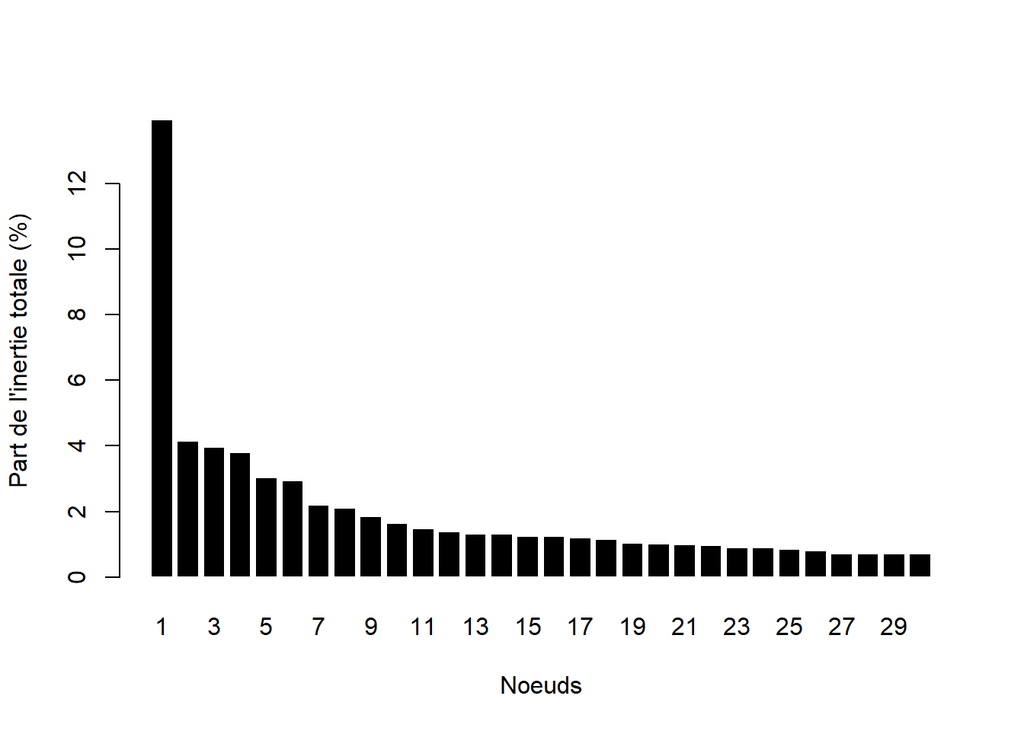

```r
sortedHeight<- sort(CAHIRIS$height,decreasing= TRUE)
relHeight<-sortedHeight/ sum(sortedHeight)*100
cumHeight<- cumsum(relHeight)

barplot(relHeight[1:30],names.arg=seq(1, 30, 1),col= "black",border= "white",xlab= "Noeuds",ylab= "Part de l'inertie totale (%)")
```

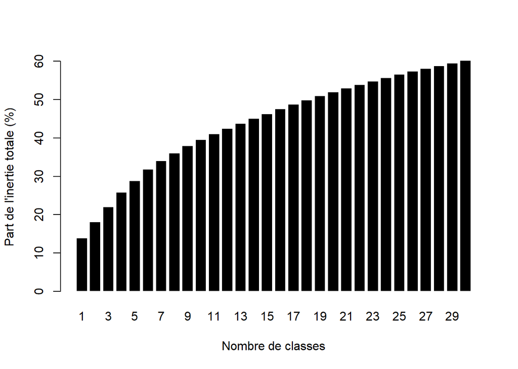

```r
barplot(cumHeight[1:30],names.arg=seq(1, 30, 1),col= "black",border= "white",xlab= "Nombre de classes",ylab= "Part de l'inertie totale (%)")
```

### 1.7.6 Arbre de classification hiérarchique (dendrogramme)

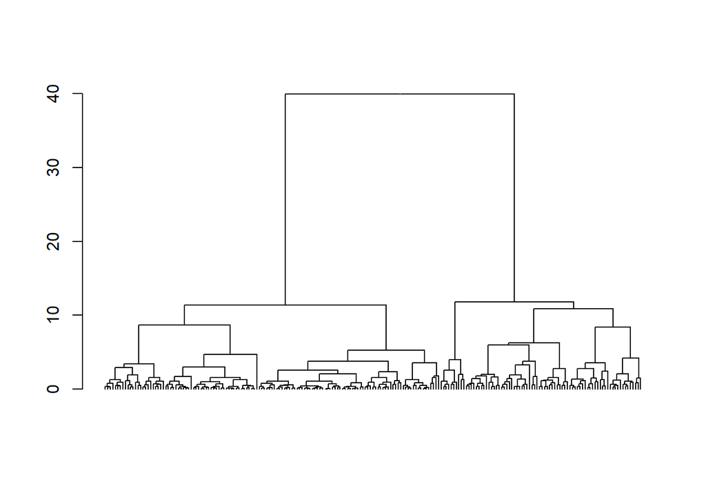

```r
dendroCSP <- as.dendrogram(CAHIRIS)
plot(dendroCSP, leaflab = "none")
```

### 1.7.7 Partition (en n classes)

```r
clusIRIS <- cutree(CAHIRIS, k = 5)
IRISCluster <- as.data.frame(IRISDVFClassif1)
IRISCluster$CLUSIMMO <- factor(clusIRIS,
                                   levels = 1:5,
                                   labels = paste("Classe", 1:5))
```

### 1.7.8 Création d’un tableau avec les caractéristiques des groupes

```r
RecapCAHIRIS <- IRISCluster %>% group_by(CLUSIMMO) %>% summarise(NB= n(), NbTransac = mean(Nbtransactions), Prixmoyen = mean(Prixmoyen), Prixm2 = mean(Prixm2moyen), Surface=mean(Surfacemoyenne), PropMaison = mean(PropMaison), PropAppart= mean(PropAppart))

print(RecapCAHIRIS)
```

```
## # A tibble: 5 x 8
##   CLUSIMMO    NB NbTransac Prixmoyen Prixm2 Surface PropMaison PropAppart
##   <fct>    <int>     <dbl>     <dbl>  <dbl>   <dbl>      <dbl>      <dbl>
## 1 Classe 1    61      46.1   240943.  2060.   126.        89.9      10.1
## 2 Classe 2    10     316.    484176.  4541.   106.        54.9      45.1
## 3 Classe 3    72      20.5   135385.  1338.   107.        93.3       6.70
## 4 Classe 4    41     274.    266156.  3551.    77.1       30.1      69.9
## 5 Classe 5    29     655.    294482.  4362.    67.7       15.0      85.0
```

### 1.7.9 Graphique des écarts à la moyenne

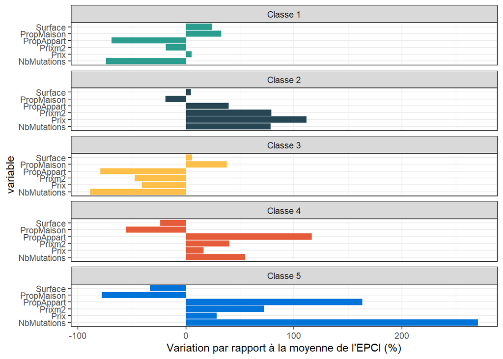

```r
SyntheseCAHIRIS <- RecapCAHIRIS %>% mutate(
  nbtransacmoy = mean(IRISDVFClassif$Nbtransactions),
  surfacemoy = mean(IRISDVFClassif$Surfacemoyenne),
  prixmoy = mean(IRISDVFClassif$Prixmoyen),
  prixm2moyen = mean(IRISDVFClassif$Prixm2moyen),
  propmaisonmoyen = mean(IRISDVFClassif$PropMaison),
  propappartmoyen = mean(IRISDVFClassif$PropAppart),
  NbMutations=(NbTransac- nbtransacmoy)/nbtransacmoy*100,
  Prix=(Prixmoyen- prixmoy)/prixmoy*100,
  Prixm2=(Prixm2- prixm2moyen)/prixm2moyen*100,
  Surface=(Surface- surfacemoy)/surfacemoy*100,
  PropMaison=(PropMaison- propmaisonmoyen)/propmaisonmoyen*100,
  PropAppart=(PropAppart- propappartmoyen)/propappartmoyen*100
)

# pour créer un nouveau tableau avec une sélection de colonnes à faire apparaître sur le graphique
SyntheseCAHIRIS <- data.frame(SyntheseCAHIRIS[, c("CLUSIMMO", "NbMutations", "Surface", "Prix", "Prixm2", "PropMaison", "PropAppart")])

gather <- SyntheseCAHIRIS %>% gather(key=variable, value= "value", NbMutations:PropAppart)

ggplot(gather, aes(x=variable, y=value, fill=CLUSIMMO)) +
  geom_bar(stat = "identity") +
  coord_flip() +
  scale_fill_manual(values=c("#2A9D8F","#264653","#fcbf49","#e45c3a","#0074D9")) +
  ylab("Variation par rapport à la moyenne de l'EPCI (%)") +
  theme_bw() +
  theme(legend.position = "none") +
  facet_wrap(~CLUSIMMO, ncol = 1)
```

### 1.7.10 Carte de la typologie montrant les sous-marchés immobiliers

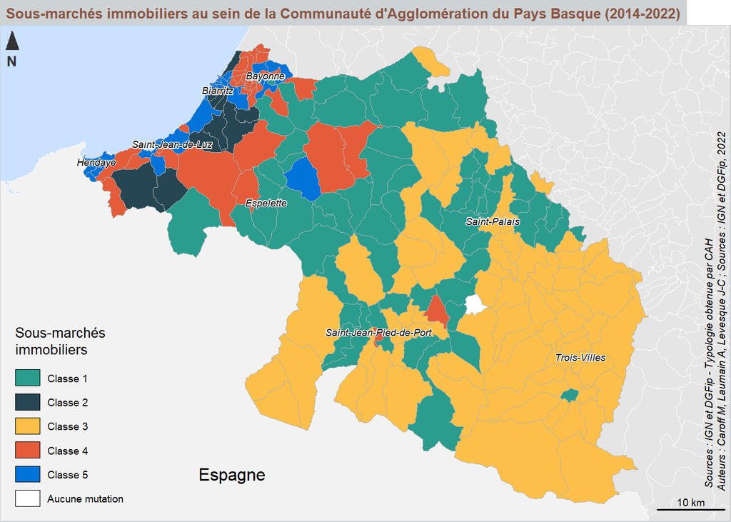

```r
# pour joindre le résultat de la typologie dans la couche des IRIS
IRISDVFCAH <- left_join(IRISBasque, IRISCluster, by= "CODE_IRIS")

# Paramétrage des marges de la fenêtre pour maximiser l'emprise de la carte
par(mar = c(0, 0, 1.2, 0))

# pour afficher la surface lissée et définir l'habillage de la carte
# Calcul des seuils
bks <- unique(getBreaks(values(cartelissee.raster), method = "q6"))

# Création d'une palette de couleurs (double gradation harmonique)
cols <- c("#2a9c4e", "#77c35c", "#c4e687", "#ffffc0", "#fec981", "#dc292c")

# Affichage des communes de notre EPCI et celles aux alentours en arrière-plan et centrage de la carte sur le Pays Basque
plot(st_geometry(Communes_Reg), lwd = 0.1, col = "grey90", border = "white", bg = "lightsteelblue1", xlim = c(st_bbox(IRISBasque)[1], st_bbox(IRISBasque)[3]), ylim = c(st_bbox(IRISBasque)[2], st_bbox(IRISBasque)[4]))

#Affichage de l'Espagne
plot(st_geometry(Espagne), lwd = 0.1, col = "grey95", border = "white", add = T)

# Affichage de la typologie et du contour des IRIS
typoLayer(
  x = IRISDVFCAH,
  var="CLUSIMMO",
  col = c("#2A9D8F","#264653","#fcbf49","#e45c3a","#0074D9"),
  lwd = 0.05,
  border = "grey70",
  legend.values.order = c("Classe 1",
                          "Classe 2",
                          "Classe 3",
                          "Classe 4",
                          "Classe 5"),
  legend.pos = "bottomleft",
  legend.title.txt = "Sous-marchés \nimmobiliers",
  legend.title.cex = 0.8,
  legend.nodata = "Aucune mutation",
  add = TRUE)

layoutLayer(title = "Sous-marchés immobiliers au sein de la Communauté d'Agglomération du Pays Basque (2014-2022)",
            author = "          Sources : IGN et DGFip - Typologie obtenue par CAH\n         Auteurs : Caroff M, Laumain A, Levesque J-C ; Sources : IGN et DGFip, 2022",
            scale = 10, frame = TRUE, col = "#cdd2d4", coltitle = "#8A5543",
            north(pos = "topleft"), tabtitle=TRUE, horiz = FALSE)


# Ajout des étiquettes des communes selectionnées plus haut
labelLayer(Selection_Communes_Pays_Basque, txt = "com_name", halo = TRUE, bg = "white", r = 0.05, cex = 0.55, pos = 3, font = 3, offset = 0, overlap = TRUE)

mtext(text = "Espagne",
      side = 3, line = -22, adj = 0.3, cex = 1, col = "#000004FF")
```

### 1.7.11 Export des IRIS contenant la typologie issue de la CAH au format geopackage (pour une utilisation dans un SIG par exemple)

```r
st_write(IRISDVFCAH, "IRISDVFCAH.gpkg", append = FALSE)
```

## 1.8 Lissage spatial des prix au m² des appartements entre 2014 et 2022 : zoom sur les communes de Biarritz, Anglet et Bayonne

### 1.8.1 Préparation du jeu de données

```r
# pour ne garder que les commmunes qui nous intéresse
Com_atlas <- Communes_Reg %>% filter(com_code == "64024" | com_code == "64102" |com_code == "64122")

# pour ne garder que les mutations correspondant à des appartements dans l'EPCI (dans un premier temps)
MutationsApptAtlas <- MutationsBasques %>% filter(type == "Appartement")

# pour créer une liste d'années, dans l'ordre
MutationsApptAtlas<-MutationsApptAtlas[order(MutationsApptAtlas$annee, decreasing = FALSE), ]
ListAnnees <- unique(MutationsApptAtlas$annee)
```

### 1.8.2 Série de cartes lissées montrant l’évolution des prix au m² des appartements calculés directement à partir des mutations entre 2014 et 2022

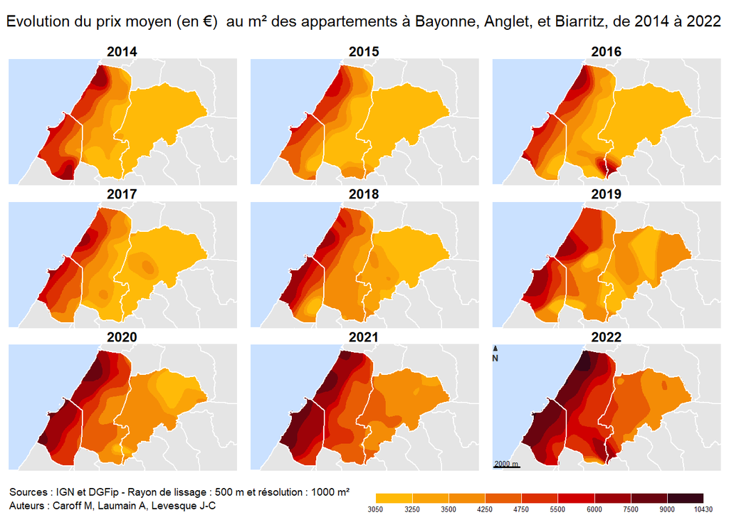

```r
# pour définir comme emprise pour le lissage, l'étendue des 3 communes avec une zone tampon de 0,5 km autour afin d'englober les mutations limitrophes et réduire l'effet de bord
EmpriseAtlas <- as.owin(as(st_union(st_buffer(Com_atlas, 500)), "Spatial"))

# Paramétrage des marges pour insérer le titre général et les titres de chaque carte
par(oma=c(3.5,0,3,0)+0.1, mar = c(0, 0.5, 1.2, 0.5))

plot.new()

# pour découper la fenêtre en 3 lignes et 3 colonnes (9 années)
par(mfrow=c(3,3))

# boucle pour produire et cartographier une surface lissée par année
for (i in ListAnnees){

  # Nommage des dataframes
  name<- paste("PrixM2_Appt_Biarritz_Anglet_Bayonne",i, sep="-")

  # Récuperation des jeux de données par année
  b<-assign(name, MutationsApptAtlas[which(MutationsApptAtlas$annee == i),]) # La fonction assign permet d'assigner un nom à une valeur/un élément
  fichier<-get(name)

  # pour récupérer les coordonnées des mutations
  pts <- st_coordinates(st_geometry(fichier))

  # pour créer un objet ppp (format spatstat) et y intégrer dans l'emprise les valeurs à lisser (prix au m²)
  fichier.ppp <- ppp(pts[,1], pts[,2], window = EmpriseAtlas, marks = fichier$prixm2)

  # pour calculer la surface lissée (rayon lissage : 500 m et résolution spatiale de l'image : 1000m²)
  cartelissee <- Smooth(fichier.ppp, sigma = 500, weights = fichier.ppp$marks, eps=sqrt(1000))

  # Conversion de la surface lissée au format raster
  cartelissee.raster <- raster(cartelissee, crs = st_crs(Com_atlas)[[2]])
  cartelissee.raster <- mask(cartelissee.raster, Com_atlas) # découpage sur l'emprise de nos communes

  # Définition manuelle des seuils
  bks <- c(cellStats(cartelissee.raster, stat='min'), 3250, 3500, 4250, 4750, 5500, 6000, 7500, 9000, cellStats(cartelissee.raster, stat='max'))

  # Création d'une palette de couleurs (double gradation harmonique)
  cols <- c("#FFBA08", "#FAA307", "#F48C06", "#E85D04", "#DC2F02", "#D00000", "#9D0208", "#6A040F", "#370617", "#03071E")

  # reclassification de la surface lissée
  cartelissee.reclass <- cut(cartelissee.raster, breaks = bks)

  # vectorisation de la surface reclassée (calcul un peu long)
  cartelissee.vecteur <- as(rasterToPolygons(cartelissee.reclass, n=4, na.rm=TRUE, digits=12, dissolve=TRUE), "sf")

  # Tracer de la carte
  plot(st_geometry(Com_atlas), border = "white", bg= "lightsteelblue1")
  plot(st_geometry(Communes_Reg), border = NA, col = "grey90", add = T)


  typoLayer(
    x = cartelissee.vecteur,
    var="layer",
    col = cols,
    lwd = 0.1,
    border = cols,
    legend.pos = "n",
    add = TRUE)

  plot(st_geometry(Communes_Reg), border = "white", add = T)

  title(main =paste("",i, sep=""))

}

barscale(
  lwd = 1.5,
  cex = 0.6,
  pos = "bottomleft",
  style = "pretty",
  unit = "m"
)

north(pos = "topleft")

# Pour afficher le titre principal et la source
mtext("Evolution du prix moyen (en €)  au m² des appartements à Bayonne, Anglet, et Biarritz, de 2014 à 2022", cex = 0.9, side=3,line=1,adj=0.5,outer=TRUE)
mtext("   Sources : IGN et DGFip - Rayon de lissage : 500 m et résolution : 1000 m²", side=1, line=1, adj=0, cex=0.6, outer=TRUE)
mtext("   Auteurs : Caroff M, Laumain A, Levesque J-C", side=1, line=2, adj=0, cex=0.6, outer=TRUE)

# Overlay the entire figure region with a new, single plot.
par(fig = c(0, 1, 0, 1), oma = c(0, 0, 0, 0), mar = c(0, 0, 0, 0), new = TRUE)
plot(0, 0, type = "n", bty = "n", xaxt = "n", yaxt = "n")


# Ajout des étiquettes des communes sélectionnées plus haut
labelLayer(Selection_Communes_Pays_Basque_Carton, txt = "com_name", halo = TRUE, bg = "white", r = 0.05, cex = 0.6, pos = 3, font = 3, offset = 0, overlap = TRUE)

# Then call legend with the location ("bottom", "right", "bottomright", etc.)

legendChoro( pos = "bottomright",
             title.txt = "",
             breaks = bks,
             nodata = FALSE,
             values.rnd = -1,
             col = cols,
             border = "white",
             horiz = TRUE)
```